# Relatório Meninas na Computação

# Análise exploratória

Agora que o dado encontra-se bem formatado, é possível explorá-lo com maior facilidade.

Como é possível notar, enquanto a maior parte das garotas encontra-se entre o não e o talvez, o grupo que entraria na ciência da computação é bem diverso, tendo em sua maioria mulheres interessadas na área de biologia e não em exatas como se esperaria.

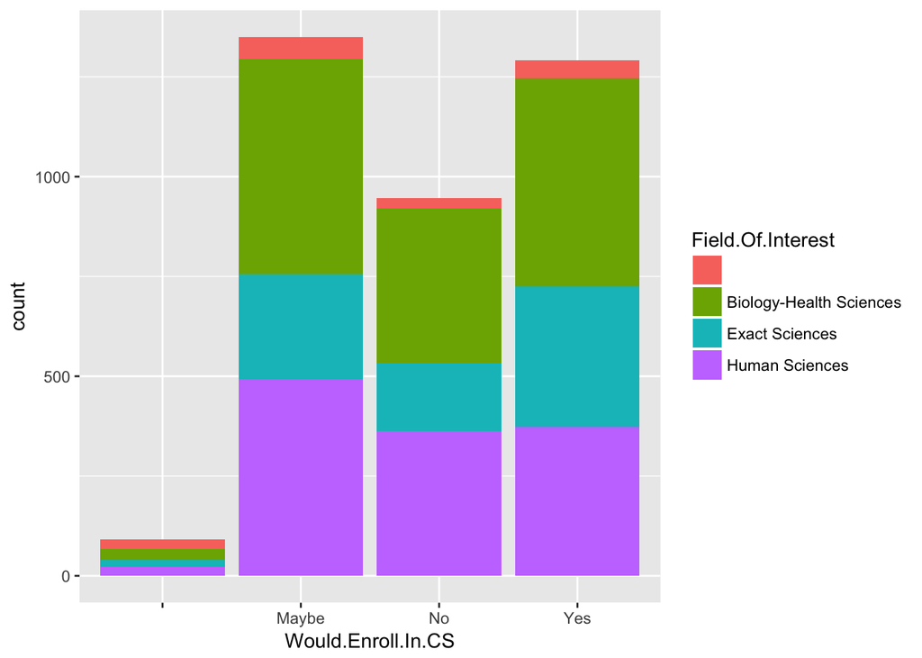

```
##
##                         Biology-Health Sciences          Exact Sciences
##                      46                     521                     353
##          Human Sciences
##                     372
```

A proporção de interessadas em biologia é consideravelmente maior do que o resto, o que explica o fato de haver tantas mulheres de biologia interessadas em ciência da computação, elas dominam todas as respostas (sim, não e talvez). E de acordo com o gráfico abaixo, que usa proporção em vez de quantidade, tal raciocínio é bem próximo da realidade.

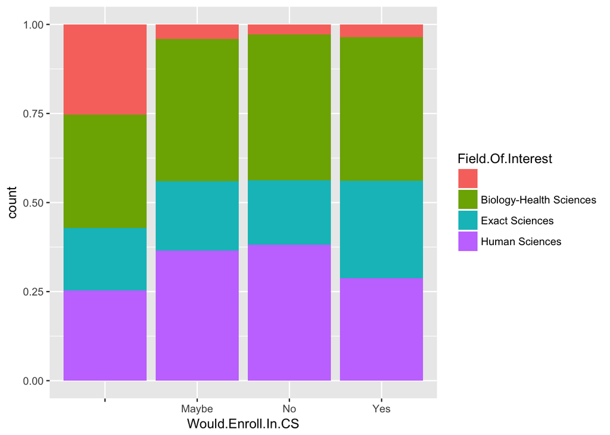

De acordo com o histograma, Biologia manteve-se próxima em porcentagem em quase todas as respostas enquanto humanas diminuiu e exatas aumentou na resposta afirmativa, o que condiz com a área de interesse.